# Wyjaśnialne uczenie maszynowe – praca domowa 5

## Wczytanie danych

Wykorzystanym zbirem danych jest Home Equity (HMEQ), zawierający informacje o 5960 klientach banku, którzy otrzymali kredyty hipoteczne.

Na podstawie zbioru próbowałam przewidzieć prawdopodobieństwo **defaultu**, czyli faktu, że klient będzie zalegał z płatnościami – określa to binarna zmienna **BAD** (1 oznacza default). Pozostałe 12 zmiennych opisuje m.in. historię kredytową aplikującego, historię zawodową oraz charakterystyki obecnej pożyczki.

Więcej informacji na temat danych można znaleźć pod linkiem https://www.kaggle.com/ajay1735/hmeq-data

## Przekształcenie danych nienumerycznych na *dummy variables*

```
{'BAD': True,
 'LOAN': True,
 'MORTDUE': True,
 'VALUE': True,
 'REASON': False,
 'JOB': False,
 'YOJ': True,
 'DEROG': True,
 'DELINQ': True,
 'CLAGE': True,
 'NINQ': True,
 'CLNO': True,
 'DEBTINC': True}
```

## Braki danych

```
BAD                  0
LOAN                 0
MORTDUE            518
VALUE              112
YOJ                515
DEROG              708
DELINQ             580
CLAGE              308
NINQ               510
CLNO               222
DEBTINC           1267
REASON_DebtCon       0
REASON_HomeImp       0
REASON_nan           0
JOB_Mgr              0
JOB_Office           0
JOB_Other            0
JOB_ProfExe          0
JOB_Sales            0
JOB_Self             0
JOB_nan              0
dtype: int64
```

### [2. For the selected data set, train at least one tree-based ensemble model (random forest, gbm, catboost or any other boosting)]

## Model – las losowy

```python
results
```

|  | accuracy_test | roc_auc_test |
| --- | --- | --- |
| RandomForest | 0.941813 | 0.895652 |

## Wyjaśnianie

### [3. Calculate permutational variable importance for the selected model]

### Las losowy

Pierwszym rozważanym modelem jest model **lasu losowego**.

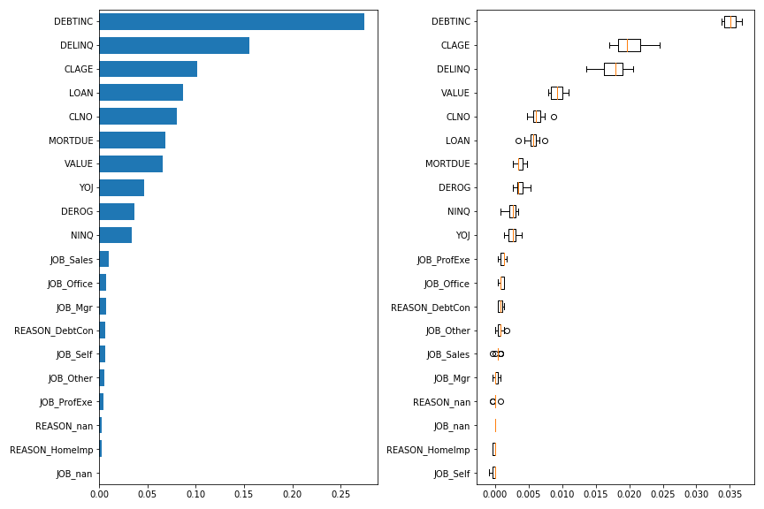

Mimo bardzo dobrych wyników predykcji wagi zmiennych w modelu nie do końca odpowiada tym, które są wynikiem permutacji zmiennych.

Zmienna *DEBTINC* (stosunek długu do dochodu) jest zdecydowanym faworytem w obu analizach, pozycje dwóch kolejnych zmiennych – *CLAGE*, czyli wiek najdłuższej otwartego rachunku oraz *DELINQ*, czyli liczba opóźnionych linii kredytowych – już się nie zgadzają. Nie są to jednak duże różnice i przy dużej rozpiętości wag, jaką możemy zaobserwować na załączonym wykresie pudełkowym, nie wydaje się być to powodem do niepokoju.

Dalsze wyniki są nieco bardziej zastanawiające: zmienna *VALUE*, czyli wartość nieruchomości pod hipoteką, wysforowała znacząco na przód w przypadku analizy opartej o permutacje zmiennych, wychodząc na czwartą pozycję, mimo że wg wag z modelu zajmuje dopiero 7 miejsce. Jest to tym bardziej zaskakujące, że w przypadku tej zmiennej nie mamy do czynienia z dużą rozpiętością wag i, poza "outlierami" granice wykresów pudełkowych nie zazębiają się.

Pozostałe zmienne również mają pewne "zawirowania" jeśli chodzi o różnice w kolejności w obu analizach, jednak przy tak dużej zmienności ich wag w analizie permutacyjnej nie jest to alarmujące.

### [4. Train three or more candidate models (different variables, different transformations, different model structures) and compare ranking of important features between these models. Are they similar or different?]

### AdaBoost

Kolejnym analizowanym modelem będzie **AdaBoost**, wytrenowany na dokładnie takim samym zbiorze danych, co **las losowy**.

```
AdaBoostClassifier(algorithm='SAMME.R',
                   base_estimator=DecisionTreeClassifier(ccp_alpha=0.0,
                                                         class_weight=None,
                                                         criterion='gini',
                                                         max_depth=7,
                                                         max_features=None,
                                                         max_leaf_nodes=None,
                                                         min_impurity_decrease=0.0,
                                                         min_impurity_split=None,
                                                         min_samples_leaf=1,
                                                         min_samples_split=2,
                                                         min_weight_fraction_leaf=0.0,
                                                         presort='deprecated',
                                                         random_state=None,
                                                         splitter='best'),
                   learning_rate=1.0, n_estimators=150, random_state=42)
```

|  | accuracy_test | roc_auc_test |
| --- | --- | --- |
| AdaBoost | 0.945873 | 0.959918 |
| RandomForest | 0.941813 | 0.895652 |

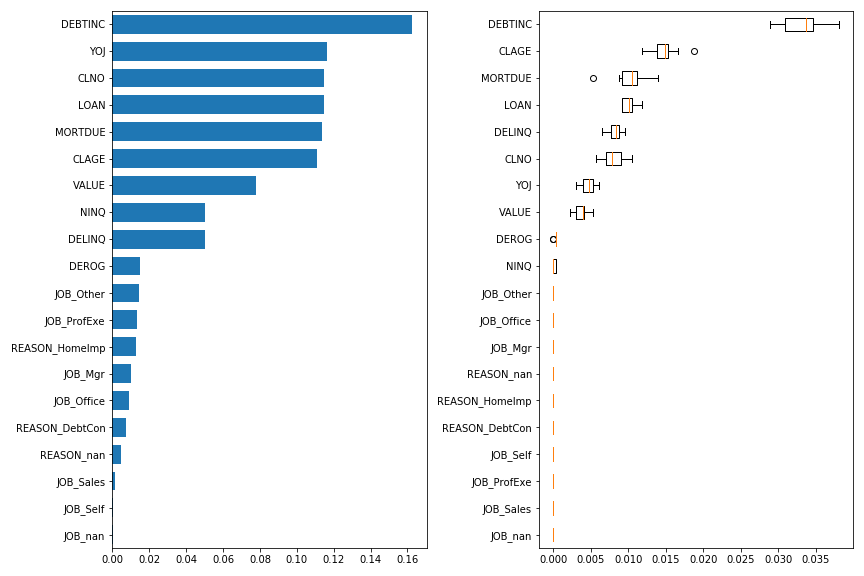

Powyżej również mamy przykład silnego lidera w postaci zmiennej *DEBTINC*, dokładnie tej samej, co w przypadku modelu lasu losowego.

Dalej jest jednak dużo ciekawiej, ponieważ, na pierwszy rzut oka przynajmniej, wszystko wydaje się nie zgadzać.

Zmienne takie jak *CLNO* (liczba linii kredytowych), *LOAN* (wnioskowana kwota pożyczki), *MORTDUE* (kwota pozostała do spłacenia na posiadanym kredycie hipotecznym) i *CLAGE* (wiek najdłuższej otwartego rachunku) mają bardzo podobne wyniki w skali adaboostowej, zaburzenia ich kolejności w analizie permutacyjnej nie powinny więc bardzo dziwić, zwłaszcza biorąc pod uwagę rozpiętość wartości wśród iteracji. Dodatkowo, ich miejsce w hierarchii jest podobne, co w modelu lasu losowego.

Wyniki zamieszczone powyżej wydają się być dużo bardziej niezgodne ze sobą niż te w modelu lasu losowego, dodatkowo te uzyskane z analizy permutacyjnej istotniej przypominają oba wykresy w poprzedniej analizie, co sugeruje gorsze dopasowanie modelu AdaBoost, mimo lepszych wyników.

Kolejnymi dwoma modelami będą również **las losowy** i **AdaBoost**, jednak tym razem trening przebiegać będzie na zbiorze danych zawierających jedynie 8 najważniejszych zmiennych (według poprzedniej analizy permutacyjnej dla danego typu modelu).

Jak widać, osiągają one niewiele gorsze rezultaty, co poprzednicy.

|  | accuracy_test | roc_auc_test |
| --- | --- | --- |
| AdaBoost | 0.947226 | 0.926409 |
| RandomForest | 0.937754 | 0.886829 |

### Las losowy z ograniczoną liczbą zmiennych

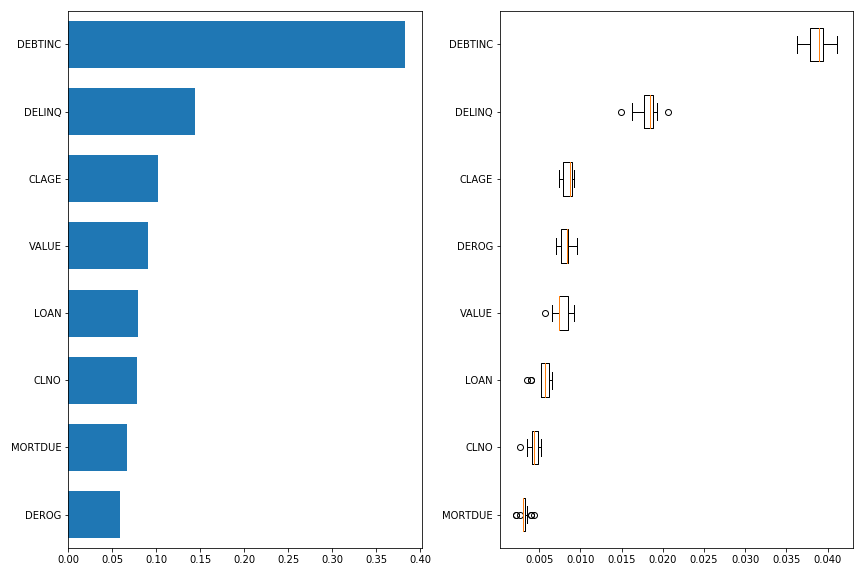

Tradycyjnie pierwsze skrzypce gra zmienna *DEBTINC* (stosunek długu do dochodu), jeszcze istotniej deklasując rywali niż w poprzednich dwóch analizach.

Dalej sytuacja się ustabilizowała i kolejne dwie zmienne, *DELINQ* oraz *CLAGE* są w odpowiedniej kolejności, co więcej, zgodnej z tą ustaloną przez pierwszy model, nie przez wagi uzyskane w wyniku permutacji – tym razem *DELINQ*, czyli liczba opóźnionych linii kredytowych, jest znacznie istotniejsza od *CLAGE*, czyli wieku najdłuższej otwartego rachunku.

W dalszej kolejności w analizie permutacyjnej możemy dostrzec uprzednio niedocenianą na wszystkich frontach zmienną *DEROG*, oznaczającą liczbę niekorzystnych raportów kredytowych – niewykluczone, że część jej wpływu była uwikłana we wkłady tych zmiennych, które zostały wyłączone z obecnego modelowania.

Pozostałe zmienne zachowują się podobnie w obu analizach, ich wyniki są także bliskie rezultatom z omawiania pierwszego modelu lasu losowego.

### AdaBoost z ograniczoną liczbą zmiennych

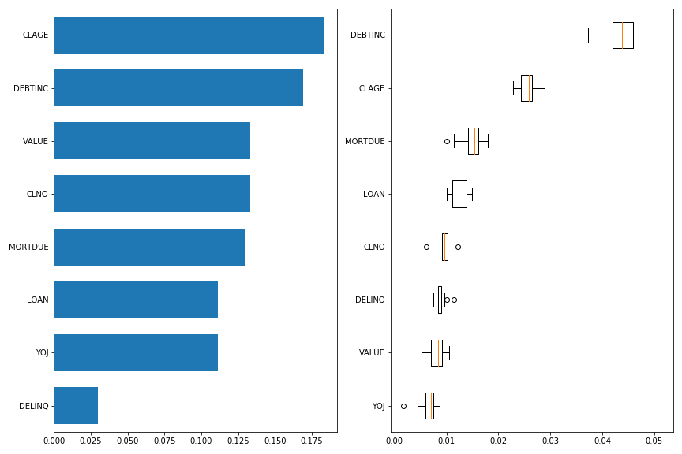

Kolejnym zaskoczeniem jest ranga zmiennej *YOJ*, czyli liczby lat w obecnej pracy: wcześniej wyniesiona przez model na zaszczytne drugie miejsce, teraz zbliżyła się do swojej odpowiedniczki z analizy permutacyjnej (najmniejszy wkład) i zajęła przedostatnią pozycję.

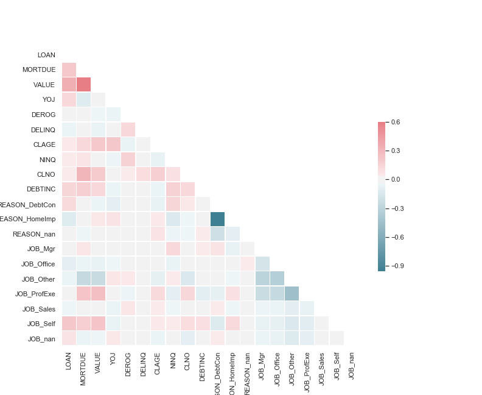

Macierz korelacji zmiennych może częściowo tłumaczyć rozbieżności w rankingu wyprodukowanym przez model oraz permutacyjnym, szczególnie dla silnie skorelowanych zmiennych jakimi są *MORTDUE*, czyli kwota pozostała do spłacenia oraz *VALUE*, czyli wartość nieruchomości i *CLNO*, czyli liczba linii kredytowych – model niejako "uśrednił" ich wpływ.

Podobnie można interpretować niską pozycję zmiennej *CLAGE* w pierwszym modelu AdaBoost: przez dość wysoką korelację ze zmienną *YOJ* (liczba lat w obecnej pracy), to ta druga "przejęła zasługi".